# Marketing_Campaign_for_Banking_Products_I S_Hrishikesh_Gadekar

## Internship Studio: Machine Learning Project (Batch: 29th July'20)

**`Submitted by: Hrishikesh Gadekar (hrishikesh.gadekar89@gmail.com)`**

### **Title: Marketing Campaign for Banking Products**

**Context:** This case is about a bank (Thera Bank) which has a growing customer base. The aim of the bank is to increase borrowers base to bring in more loan business and earn more through the interest on loans. So, the bank wants to convert the liability based customers to personal loan customers. Bank's last year campaign showed a healthy conversion rate of over 9% success. The department wants to build a model that will help them identify the potential customers who have higher probability of purchasing the loan. This will increase the success ratio while at the same time reduce the cost of the campaign.

In this project, we will apply various models on the dataset and choose the best one using certain criterion.

###### ----------------------------------------------------------------------------------------------------------------------------------------------------------------------------------------------------------------------------------

#### **1) Import Libraries and Dataset:**

First we will import all the required Python Libraries-

```python
import pandas as pd                  # Pandas: For reading the CSV Dataset file, creating DataFrames and performing analysis
import numpy as np                   # NumPy: For suitable array operations in an easier way
import seaborn as sns                # Seaborn: For the purpose of visualization of data using various plots
import matplotlib.pyplot as plt      # Matplotlib: For plotting the graphs
%matplotlib inline
# SciKit learn: The Python library for scientific ML techniques
from sklearn.preprocessing import PowerTransformer
from sklearn.preprocessing import StandardScaler
from sklearn.model_selection import train_test_split
from sklearn.metrics import confusion_matrix
from sklearn.metrics import plot_confusion_matrix
from sklearn.metrics import classification_report
from sklearn.metrics import accuracy_score
from sklearn.metrics import f1_score
from sklearn.linear_model import LogisticRegression
from sklearn.neighbors import KNeighborsClassifier
from sklearn.tree import DecisionTreeClassifier
from sklearn.naive_bayes import GaussianNB
from sklearn.ensemble import RandomForestClassifier
from sklearn.model_selection import KFold
from sklearn.model_selection import cross_val_score
from sklearn.metrics import roc_curve,auc,roc_auc_score
from  sklearn.utils import resample
sns.set_style("white")               # The plots color style is set to 'white'
pd.options.mode.chained_assignment = None
```

Reading the Dataset using Pandas and then converting it to DataFrame df-

```python
dc = pd.read_excel('datasets_48024_87370_Bank_Personal_Loan_Modelling.xlsx')
df = pd.DataFrame(dc)
```

```python
# Let's see if we have correctly imported the data
df.head()
```

|  | ID | Age | Experience | Income | ZIP Code | Family | CCAvg | Education | Mortgage | Personal Loan | Securities Account | CD Account | Online | CreditCard |
| --- | --- | --- | --- | --- | --- | --- | --- | --- | --- | --- | --- | --- | --- | --- |
| 0 | 1 | 25 | 1 | 49 | 91107 | 4 | 1.6 | 1 | 0 | 0 | 1 | 0 | 0 | 0 |
| 1 | 2 | 45 | 19 | 34 | 90089 | 3 | 1.5 | 1 | 0 | 0 | 1 | 0 | 0 | 0 |
| 2 | 3 | 39 | 15 | 11 | 94720 | 1 | 1.0 | 1 | 0 | 0 | 0 | 0 | 0 | 0 |
| 3 | 4 | 35 | 9 | 100 | 94112 | 1 | 2.7 | 2 | 0 | 0 | 0 | 0 | 0 | 0 |
| 4 | 5 | 35 | 8 | 45 | 91330 | 4 | 1.0 | 2 | 0 | 0 | 0 | 0 | 0 | 1 |

```python
df.tail()
```

|  | ID | Age | Experience | Income | ZIP Code | Family | CCAvg | Education | Mortgage | Personal Loan | Securities Account | CD Account | Online | CreditCard |
| --- | --- | --- | --- | --- | --- | --- | --- | --- | --- | --- | --- | --- | --- | --- |
| 4995 | 4996 | 29 | 3 | 40 | 92697 | 1 | 1.9 | 3 | 0 | 0 | 0 | 0 | 1 | 0 |
| 4996 | 4997 | 30 | 4 | 15 | 92037 | 4 | 0.4 | 1 | 85 | 0 | 0 | 0 | 1 | 0 |
| 4997 | 4998 | 63 | 39 | 24 | 93023 | 2 | 0.3 | 3 | 0 | 0 | 0 | 0 | 0 | 0 |
| 4998 | 4999 | 65 | 40 | 49 | 90034 | 3 | 0.5 | 2 | 0 | 0 | 0 | 0 | 1 | 0 |
| 4999 | 5000 | 28 | 4 | 83 | 92612 | 3 | 0.8 | 1 | 0 | 0 | 0 | 0 | 1 | 1 |

#### **2) Data Summary:**

Now we will check our DataFrame df's brief information, datatypes in our columns and all other summary

```python
df.info()
```

```
<class 'pandas.core.frame.DataFrame'>
RangeIndex: 5000 entries, 0 to 4999
Data columns (total 14 columns):
 #   Column              Non-Null Count  Dtype
---  ------              --------------  -----
 0   ID                  5000 non-null   int64
 1   Age                 5000 non-null   int64
 2   Experience          5000 non-null   int64
 3   Income              5000 non-null   int64
 4   ZIP Code            5000 non-null   int64
 5   Family              5000 non-null   int64
 6   CCAvg               5000 non-null   float64
 7   Education           5000 non-null   int64
 8   Mortgage            5000 non-null   int64
 9   Personal Loan       5000 non-null   int64
 10  Securities Account  5000 non-null   int64
 11  CD Account          5000 non-null   int64
 12  Online              5000 non-null   int64
 13  CreditCard          5000 non-null   int64
dtypes: float64(1), int64(13)
memory usage: 547.0 KB
```

As we can see, we have a total of **5000 rows** in our Dataset, all without any null value.

```python
df.dtypes
```

```
ID                      int64
Age                     int64
Experience              int64
Income                  int64
ZIP Code                int64
Family                  int64
CCAvg                 float64
Education               int64
Mortgage                int64
Personal Loan           int64
Securities Account      int64
CD Account              int64
Online                  int64
CreditCard              int64
dtype: object
```

```python
df.describe().transpose()
```

|  | count | mean | std | min | 25% | 50% | 75% | max |
| --- | --- | --- | --- | --- | --- | --- | --- | --- |
| ID | 5000.0 | 2500.500000 | 1443.520003 | 1.0 | 1250.75 | 2500.5 | 3750.25 | 5000.0 |
| Age | 5000.0 | 45.338400 | 11.463166 | 23.0 | 35.00 | 45.0 | 55.00 | 67.0 |
| Experience | 5000.0 | 20.104600 | 11.467954 | -3.0 | 10.00 | 20.0 | 30.00 | 43.0 |
| Income | 5000.0 | 73.774200 | 46.033729 | 8.0 | 39.00 | 64.0 | 98.00 | 224.0 |
| ZIP Code | 5000.0 | 93152.503000 | 2121.852197 | 9307.0 | 91911.00 | 93437.0 | 94608.00 | 96651.0 |
| Family | 5000.0 | 2.396400 | 1.147663 | 1.0 | 1.00 | 2.0 | 3.00 | 4.0 |
| CCAvg | 5000.0 | 1.937913 | 1.747666 | 0.0 | 0.70 | 1.5 | 2.50 | 10.0 |
| Education | 5000.0 | 1.881000 | 0.839869 | 1.0 | 1.00 | 2.0 | 3.00 | 3.0 |
| Mortgage | 5000.0 | 56.498800 | 101.713802 | 0.0 | 0.00 | 0.0 | 101.00 | 635.0 |
| Personal Loan | 5000.0 | 0.096000 | 0.294621 | 0.0 | 0.00 | 0.0 | 0.00 | 1.0 |
| Securities Account | 5000.0 | 0.104400 | 0.305809 | 0.0 | 0.00 | 0.0 | 0.00 | 1.0 |
| CD Account | 5000.0 | 0.060400 | 0.238250 | 0.0 | 0.00 | 0.0 | 0.00 | 1.0 |
| Online | 5000.0 | 0.596800 | 0.490589 | 0.0 | 0.00 | 1.0 | 1.00 | 1.0 |
| CreditCard | 5000.0 | 0.294000 | 0.455637 | 0.0 | 0.00 | 0.0 | 1.00 | 1.0 |

```python
df.shape
```

```
(5000, 14)
```

```python
print(df.index)
print('')
print(df.columns)
```

```
RangeIndex(start=0, stop=5000, step=1)

Index(['ID', 'Age', 'Experience', 'Income', 'ZIP Code', 'Family', 'CCAvg',
       'Education', 'Mortgage', 'Personal Loan', 'Securities Account',
       'CD Account', 'Online', 'CreditCard'],
      dtype='object')
```

```python
df[df.isnull()].count()
```

```
ID                    0
Age                   0
Experience            0
Income                0
ZIP Code              0
Family                0
CCAvg                 0
Education             0
Mortgage              0
Personal Loan         0
Securities Account    0
CD Account            0
Online                0
CreditCard            0
dtype: int64
```

```python
df.skew(numeric_only=True)
```

```
ID                     0.000000
Age                   -0.029341
Experience            -0.026325
Income                 0.841339
ZIP Code             -12.500221
Family                 0.155221
CCAvg                  1.598457
Education              0.227093
Mortgage               2.104002
Personal Loan          2.743607
Securities Account     2.588268
CD Account             3.691714
Online                -0.394785
CreditCard             0.904589
dtype: float64
```

```python
df[df<0].count()
```

```
ID                     0
Age                    0
Experience            52
Income                 0
ZIP Code               0
Family                 0
CCAvg                  0
Education              0
Mortgage               0
Personal Loan          0
Securities Account     0
CD Account             0
Online                 0
CreditCard             0
dtype: int64
```

Like we had observed earlier, **no null values**.

```python
#finding unique data
df.apply(lambda x: len(x.unique()))
```

```
ID                    5000
Age                     45
Experience              47
Income                 162
ZIP Code               467
Family                   4
CCAvg                  108
Education                3
Mortgage               347
Personal Loan            2
Securities Account       2
CD Account               2
Online                   2
CreditCard               2
dtype: int64
```

#### **3) Data Cleaning**

Now we will move on to the next step of cleaning the data by checking for any missing or infeasible data. This will make the Dataset make suitable for applying Machine Learning algorithms

As we can observe from our last cell results, some of the values are negative, which is not possible since the range of the variable 'Experience' is [0, inf]. We will set the negative values to the median of the remaining values in that column. The reason for choosing Median and not Mean is that Mean is sensitive to outliers in the Dataset while the Median is not.

```python
df[df['Experience'] < 0]['Experience'].count()
```

```
52
```

```python
# Setting the negative values equal to the Median
lmdvalue = int(df['Experience'].median())
for i in range(len(df)):
    if df['Experience'].iloc[i] < 0:
        df['Experience'].iloc[i] = lmdvalue
```

```python
# Now checking if there are any records with negative experience
df[df['Experience'] < 0]['Experience'].count()
```

```
0
```

```python
# Let's set ID column as the Index column since it will not affect the Model prediction
df.set_index(['ID'], inplace=True)
df.head()
```

| ID | Age | Experience | Income | ZIP Code | Family | CCAvg | Education | Mortgage | Personal Loan | Securities Account | CD Account | Online | CreditCard |
| --- | --- | --- | --- | --- | --- | --- | --- | --- | --- | --- | --- | --- | --- |
| 1 | 25 | 1 | 49 | 91107 | 4 | 1.6 | 1 | 0 | 0 | 1 | 0 | 0 | 0 |
| 2 | 45 | 19 | 34 | 90089 | 3 | 1.5 | 1 | 0 | 0 | 1 | 0 | 0 | 0 |
| 3 | 39 | 15 | 11 | 94720 | 1 | 1.0 | 1 | 0 | 0 | 0 | 0 | 0 | 0 |
| 4 | 35 | 9 | 100 | 94112 | 1 | 2.7 | 2 | 0 | 0 | 0 | 0 | 0 | 0 |
| 5 | 35 | 8 | 45 | 91330 | 4 | 1.0 | 2 | 0 | 0 | 0 | 0 | 0 | 1 |

```python
# To avoid the inconvenience, let's lowercase all the column labels
df.columns = [i.lower() for i in df.columns]
df.columns
```

```
Index(['age', 'experience', 'income', 'zip code', 'family', 'ccavg',
       'education', 'mortgage', 'personal loan', 'securities account',
       'cd account', 'online', 'creditcard'],
      dtype='object')
```

#### **4) Exploratory Data Analysis (EDA):**

Let us visualize the given Dataset using Seaborn library plots so that we can get some idea of the various patterns, if any. Let's first go sequentially with the tasks assigned as per the project document.

```python
# Finding the number of unique values in each of the columns
df.nunique()
```

```
age                    45
experience             44
income                162
zip code              467
family                  4
ccavg                 108
education               3
mortgage              347
personal loan           2
securities account      2
cd account              2
online                  2
creditcard              2
dtype: int64
```

Taking a deeper dive into the **nature of Features** or Variables-

```
1) ID: We have already set this as our Index column. Can be safely omitted from EDA.

2) Age: The Customer's age is a Numerical data of type Interval.

3) Income: Annual Income of customers is a Numerical data of type Interval. One of the key feature for our Model prediction.

4) ZIP Code: Home address of the Customers. Need not be considered in EDA.

5) Family: Family size of the customer. This is an Ordinal Categorical variable.

6) CC Avg.:  Credit cards spending per month ($000). This is a Numerical data of type Interval which will give us an idea of the overall economic level of a Customer.

7) Education: This is an Ordinal categorical data type.

8) Mortgage: This Numerical data of type Interval gives the value of House mortgage.

9) Personal Loan: This is our feature to be predicted. The data in the column is Categorical and Binary type.

10) Securities Account: This Categorical data of Binary type indicates if the Customer has an account in the bank.

11) CD Account: This is one of our Categorical data columns of type Binary.

12) Online: This Categorical data of Binary type tells if the Customer has an Online Account.

13) Credit Card: This Categotical data of Binary type tells about possession of Credit card by the Customer.
```

With this, we can broadly divide our Dataset into

```
A) Numerical: ['age', 'experience', 'income', 'zip code', 'ccavg', 'mortgage']

B) Categorical: ['personal loan', 'securities account', 'family', 'education', 'cd account', 'online', 'creditcard']
```

```python
# Let's find the Columns having Numerical data
numeric_features = df.select_dtypes(include=[np.number])
numeric_features.columns
```

```
Index(['age', 'experience', 'income', 'zip code', 'family', 'ccavg',
       'education', 'mortgage', 'personal loan', 'securities account',
       'cd account', 'online', 'creditcard'],
      dtype='object')
```

```python
numeric_features.head()
```

| ID | age | experience | income | zip code | family | ccavg | education | mortgage | personal loan | securities account | cd account | online | creditcard |
| --- | --- | --- | --- | --- | --- | --- | --- | --- | --- | --- | --- | --- | --- |
| 1 | 25 | 1 | 49 | 91107 | 4 | 1.6 | 1 | 0 | 0 | 1 | 0 | 0 | 0 |
| 2 | 45 | 19 | 34 | 90089 | 3 | 1.5 | 1 | 0 | 0 | 1 | 0 | 0 | 0 |
| 3 | 39 | 15 | 11 | 94720 | 1 | 1.0 | 1 | 0 | 0 | 0 | 0 | 0 | 0 |
| 4 | 35 | 9 | 100 | 94112 | 1 | 2.7 | 2 | 0 | 0 | 0 | 0 | 0 | 0 |
| 5 | 35 | 8 | 45 | 91330 | 4 | 1.0 | 2 | 0 | 0 | 0 | 0 | 0 | 1 |

```python
# Finding the number of people with zero Mortgage value
df[df['mortgage'] == 0]['mortgage'].count()
```

```
3462
```

```python
# Finding the number of people with no Credit card spending per month
df[df['ccavg'] == 0]['ccavg'].count()
```

```
106
```

Now we will find the **Value counts** of our Categorical columns-

```python
df['education'].value_counts()
```

```
1    2096
3    1501
2    1403
Name: education, dtype: int64
```

```python
df['personal loan'].value_counts()
```

```
0    4520
1     480
Name: personal loan, dtype: int64
```

```python
df['securities account'].value_counts()
```

```
0    4478
1     522
Name: securities account, dtype: int64
```

```python
df['cd account'].value_counts()
```

```
0    4698
1     302
Name: cd account, dtype: int64
```

```python
df['online'].value_counts()
```

```
1    2984
0    2016
Name: online, dtype: int64
```

```python
df['creditcard'].value_counts()
```

```
0    3530
1    1470
Name: creditcard, dtype: int64
```

Now that we have found out the counts of these categorical columns, let's see how many customers who bought the Personal loan use other services provided by the bank.

```python
df_ser = df[['personal loan', 'securities account', 'cd account', 'online', 'creditcard']]
df_serg= df_ser.groupby('personal loan').sum()
df_serg
```

| personal loan | securities account | cd account | online | creditcard |
| --- | --- | --- | --- | --- |
| 0 | 462 | 162 | 2693 | 1327 |
| 1 | 60 | 140 | 291 | 143 |

```python
df_serg.describe().T
```

|  | count | mean | std | min | 25% | 50% | 75% | max |
| --- | --- | --- | --- | --- | --- | --- | --- | --- |
| securities account | 2.0 | 261.0 | 284.256926 | 60.0 | 160.5 | 261.0 | 361.5 | 462.0 |
| cd account | 2.0 | 151.0 | 15.556349 | 140.0 | 145.5 | 151.0 | 156.5 | 162.0 |
| online | 2.0 | 1492.0 | 1698.470488 | 291.0 | 891.5 | 1492.0 | 2092.5 | 2693.0 |
| creditcard | 2.0 | 735.0 | 837.214429 | 143.0 | 439.0 | 735.0 | 1031.0 | 1327.0 |

Coming to **Univariate Analysis** using different plots:

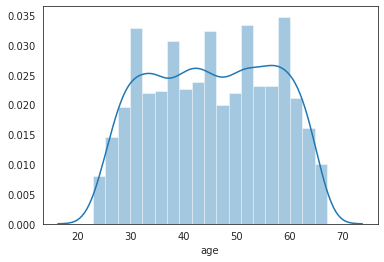

```python
sns.distplot(df['age'], kde=True);
```

*Observation*: We can see a Multi-modal distribution of the 'Age' variable.

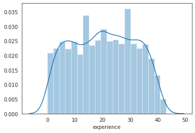

```python
sns.distplot(df['experience']);
```

*Observation*: Again, we can see a Multi-modal and uniform distribution of the 'Experience' variable.

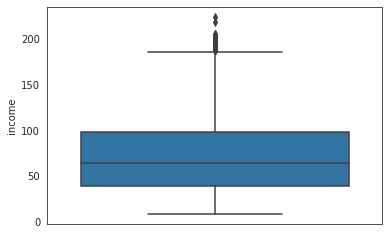

```python
sns.boxplot(df['income'], orient='vertical');
```

*Observation*: We can observe the Median 'Income' to be around $60,000 and there are a lot ou Outliers as well.

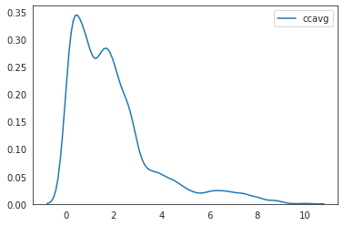

```python
sns.kdeplot(df['ccavg']);
```

*Observation*: A large number of customers spend between $1000-3000 with their Credit cards.

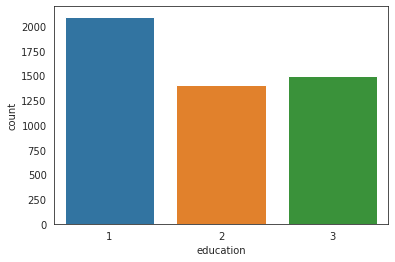

```python
sns.countplot(df['education']);
```

*Observation*: The proportion of education level of our customers is: Undergraduates > Professionals > Graduate

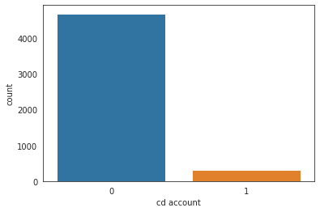

```python
sns.countplot(df['cd account']);
```

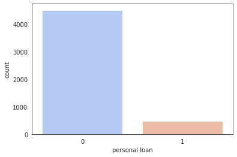

```python
sns.countplot(df['personal loan'], palette='coolwarm');
```

*Observation*: A very less portion of Customers accepted a Personal loan in the previous campaign.

Let's now perform some **Bivariate Analysis**.

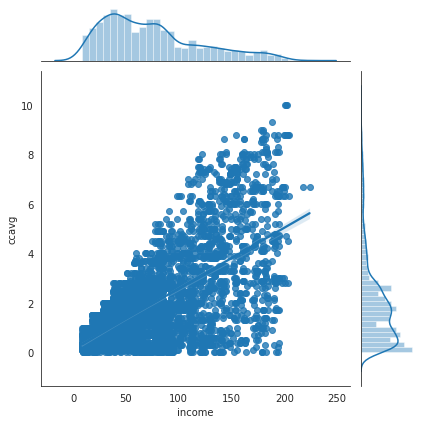

```python
sns.jointplot(x='income',y='ccavg',data=df,kind='reg');
```

*Observation*: As intuitive, Credit Card spending is increasing with teh Income level.

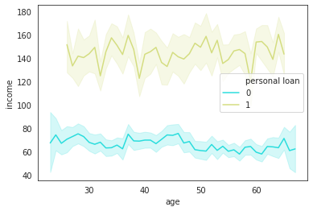

```python
sns.lineplot(x="age", y="income", hue='personal loan', data=df,palette='rainbow');
```

*Observation*: We can see that the Customers who accepted the Personal Loan have a relatively higher income than who did not accept it.

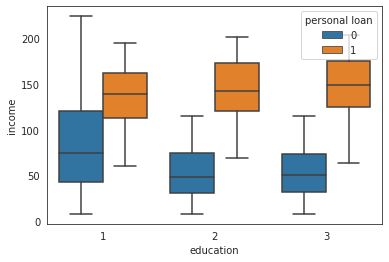

```python
sns.boxplot(x='education', y='income', hue='personal loan', data=df);
```

*Observation*: We can observe the Income level of the Customers who accepted a Personal Loan is higher for every Education level.

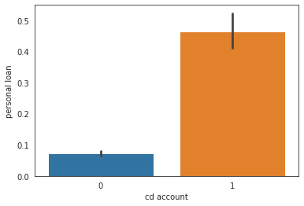

```python
sns.barplot(x='cd account', y='personal loan', data=df);
```

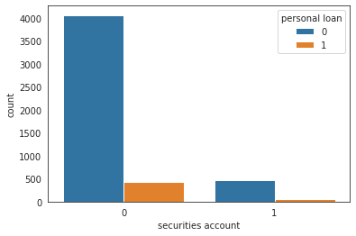

```python
sns.countplot(x='securities account', hue='personal loan', data=df);
```

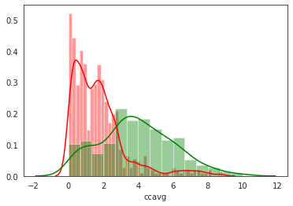

```python
sns.distplot( df[df['personal loan']== 0]['ccavg'], color = 'r');
sns.distplot( df[df['personal loan'] == 1]['ccavg'], color = 'g');
```

*Observation*: We can see that Customers accepting a Personal loan have higher Credit card spending.

Finally let's try **Multivariate Analysis** now:

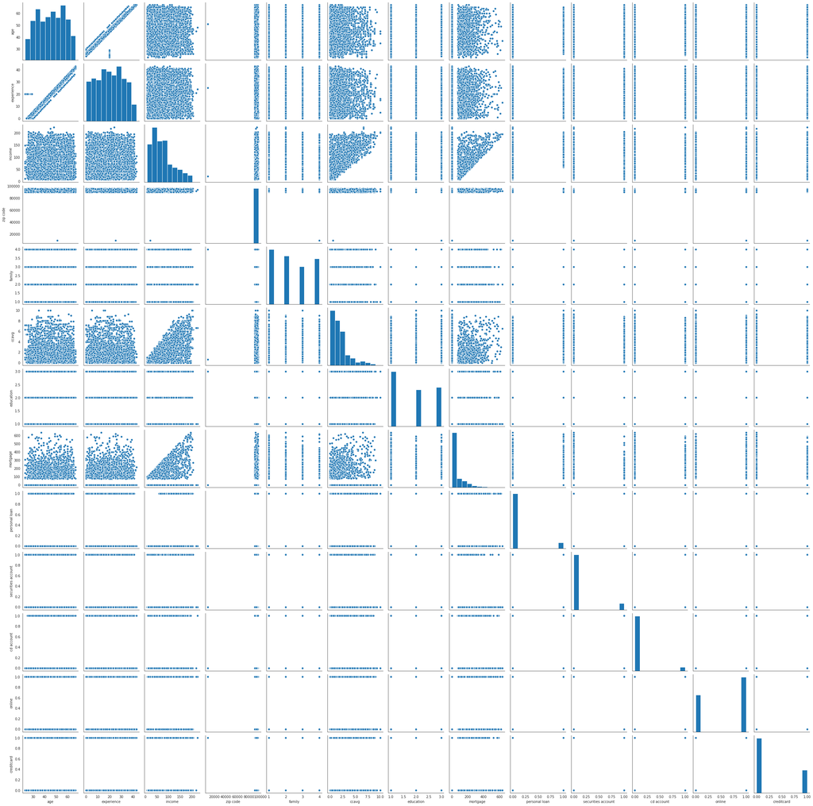

```python
# A pairplot to get a broader perspective
sns.pairplot(df, palette='coolwarm');
```

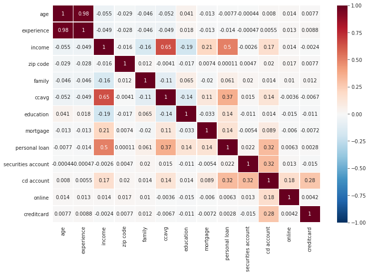

```python
plt.figure(figsize=(12,8))
sns.heatmap(df.corr(), annot=True, vmin=-1,vmax=1,center=0, cmap='RdBu_r',linecolor='white',linewidths=0.25);
```

*Observation*: We can see that 'Age' and 'Experience' are highly correlated.

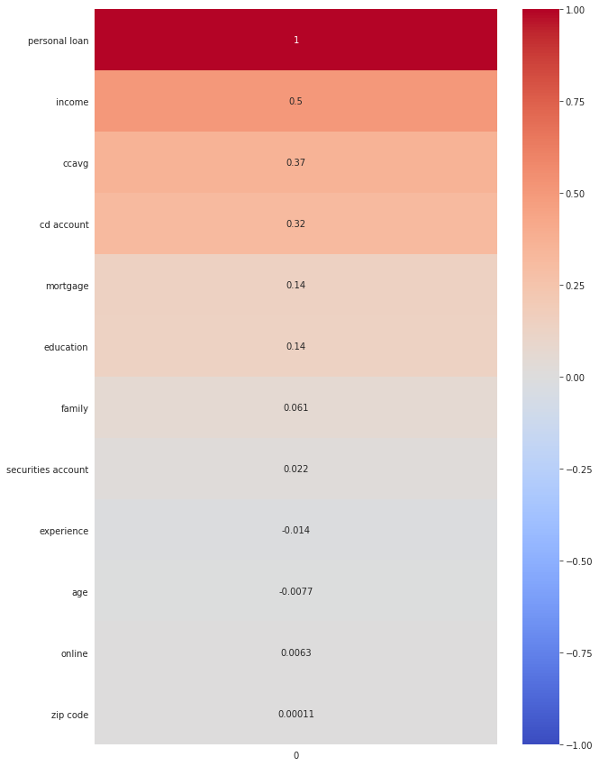

```python
#correlation between all of the numeric variables in the data frame and the target-personal_loan
#Pandas’ corrwith() method return a pair-wise correlation
correlations = df.corrwith(df['personal loan']).iloc[:-1].to_frame()
correlations['abs'] = correlations[0].abs()
sorted_correlations = correlations.sort_values('abs', ascending=False)[0]
fig, ax = plt.subplots(figsize=(10,15))
sns.heatmap(sorted_correlations.to_frame(), cmap='coolwarm', annot=True, vmin=-1, vmax=1, ax=ax);
```

#### **5) Train-Test Dataset split & Feature Inspection and Transformation**

In this part, we will have a close check at the distribution of all the features in our Dataset.

Before that, let's check the distribution of our target 'personal loan' column.

```python
df['personal loan'].value_counts()
```

```
0    4520
1     480
Name: personal loan, dtype: int64
```

Now, there is an important thing to note. As you could see, our Target variable is not equally distributed, only around 10% of customers have accepted the Personal Loan. So, if our model is going to learn from this dataset and do the prediction chances are there that it might be biased towards the Majority class (In this case , Personal loan not being accepted by the customer) and ignore the minority class. Hence , we should try to balance our dataset to make our model learn and predict with being biased and treat both classes equally for better result. A balanced Dataset is essential for unbiased predictions from our model. We need to come up with a solution to ensure that our model does not make any biased decisions.

There are a couple of ways to achieve this and this technique is called **Resampling**.

For this problem, we will try *Upsampling* since we wish to have a greater number of customers having accepted the loan.

```python
df_maj = df[df['personal loan']==0]
df_min = df[df['personal loan']==1]
df_upsample_min = resample(df_min, replace=True, random_state=12, n_samples=4520)
df_upsample = pd.concat([df_maj, df_upsample_min])
```

Let's check the distribution after performing the Upsampling.

```python
df_upsample['personal loan'].value_counts()
```

```
1    4520
0    4520
Name: personal loan, dtype: int64
```

**5.1) Splitting the Dataset**

We will split our Dataset into a Training data and a Test data set, in the ratio of 70:30. The *stratify* parameter of train_test_split function will be used to get the same class distribution across our train and the test data set.

5.1.1) Splitting the main data

```python
# Let's first separate out our output column 'personal loan' from df

data_X = df.loc[:, df.columns != "personal loan"]
data_Y = df[["personal loan"]]
```

```python
X_train, X_test ,y_train, y_test = train_test_split(data_X, data_Y, test_size=0.30, stratify=data_Y, random_state=0)
X_train.reset_index(drop=True, inplace=True);
X_test.reset_index(drop=True, inplace=True);
y_train.reset_index(drop=True, inplace=True);
y_test.reset_index(drop=True, inplace=True);
```

5.1.2) Splitting the upsampled data

```python
# Let's first separate out our output column 'personal loan' from df_upsampled
X_upsampled = df_upsample.drop(['personal loan'],axis=1)
Y_upsampled = df_upsample['personal loan']
```

```python
X_upsampled_train, X_upsampled_test, Y_upsampled_train, Y_upsampled_test = train_test_split(X_upsampled, Y_upsampled, test_size=0.3, stratify=Y_upsampled, random_state=0)
X_upsampled_train.reset_index(drop=True, inplace=True);
X_upsampled_test.reset_index(drop=True, inplace=True);
Y_upsampled_train.reset_index(drop=True, inplace=True);
X_upsampled_test.reset_index(drop=True, inplace=True);
```

So now we have two sets of Training as well as Test data. We perform all the further operations on both of these sets.

**5.2) Feature Inspection and Transformation**

Now, let's check each of our Numerical & Ordinal Categorical features in X_train set for **Skewness** and **Outliers**. Outliers affect the learning performance thus it is very essential to perform Outlier analysis for each feature, one-by-one. For each feature, we will check two plot, Normalized histogram using distplot() to check Skewness and Boxplot to check for Outliers.Then, for Skewed data, we will apply suitable Transformation to remove the Outliers and reduce the Skewness. *Outliers Analysis is not required for other Nominal or Binary Categorical features*.

**`Note: For each of the features, we check its distribution in the Main as well as the Upsampled Dataset. Thus, there will be two plots shown for each feature.`**

```
Feature 1: 'Age' is our Numerical Interval data.
```

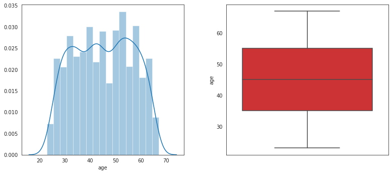

```python
# Main Data
fig, axes = plt.subplots(1, 2, figsize=(12,6))

sns.distplot(X_train["age"], ax=axes[0]);
sns.boxplot(X_train["age"], orient="vertical", ax=axes[1], palette = 'Set1')

fig.tight_layout(pad=5.0)
```

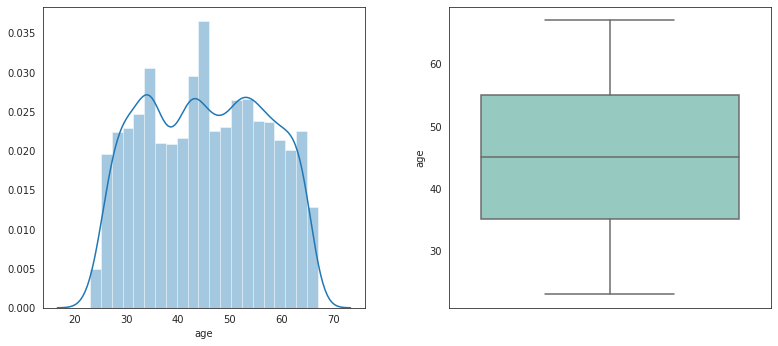

```python
# Upsampled Data
fig, axes = plt.subplots(1, 2, figsize=(12,6))

sns.distplot(X_upsampled_train["age"], ax=axes[0]);
sns.boxplot(X_upsampled_train["age"], orient="vertical", ax=axes[1], palette = 'Set3')

fig.tight_layout(pad=5.0)
```

*Observation*: There are no Outliers for the 'Age' feature in both the Datasets.

```
Feature 2: 'Experience' is our Numerical Interval data.
```

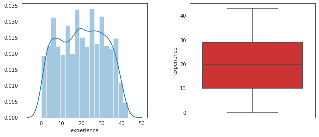

```python
# Main Data
fig, axes = plt.subplots(1, 2, figsize=(10,5))

sns.distplot(X_train["experience"], ax=axes[0]);
sns.boxplot(X_train["experience"], orient="vertical", palette="Set1", ax=axes[1])

fig.tight_layout(pad=5.0)
```

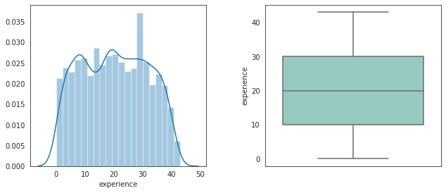

```python
# Upsampled Data
fig, axes = plt.subplots(1, 2, figsize=(10,5))

sns.distplot(X_upsampled_train["experience"], ax=axes[0]);
sns.boxplot(X_upsampled_train["experience"], orient="vertical", palette="Set3", ax=axes[1])

fig.tight_layout(pad=5.0)
```

*Observation*: There are no Outliers for the 'Experience' feature in both the datasets.

```
Feature 3: 'Income' is our Numerical Interval data.
```

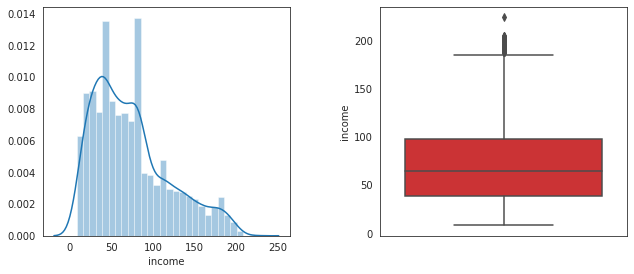

```python
# Main Data
fig, axes = plt.subplots(1, 2, figsize=(10,5))

sns.distplot(X_train["income"], ax=axes[0]);
sns.boxplot(X_train["income"], orient="v", palette="Set1", ax=axes[1]);

fig.tight_layout(pad=5.0)
```

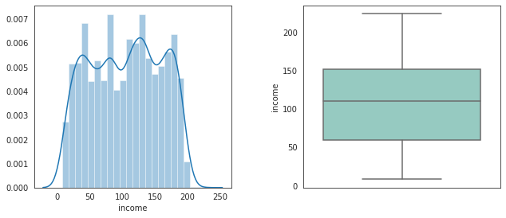

```python
# Upsampled Data
fig, axes = plt.subplots(1, 2, figsize=(10,5))

sns.distplot(X_upsampled_train["income"], ax=axes[0]);
sns.boxplot(X_upsampled_train["income"], orient="v", palette="Set3", ax=axes[1]);

fig.tight_layout(pad=5.0)
```

*Observation*: Now, the distribution in the Upsampled Dataset is uniform. However, we have a highly skewed Distribution of the Income feature in the Main Dataset. It can be classified as a log-normal distribution which means if we apply log transformation to Income, resulting distribution will be similar to a Gaussian. We will use the **Yeo-Johnson** method from scikit-learn PowerTransformer. The resulting distribution is as shown below:

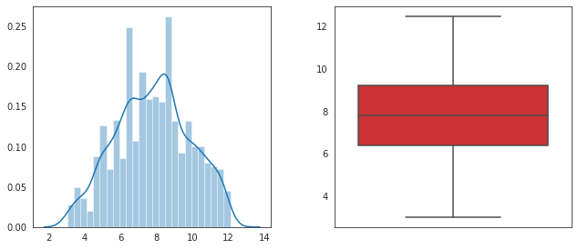

```python
# Transformation on the Main data X_train
pt_income = PowerTransformer(method="yeo-johnson", standardize=False)

pt_income.fit(X_train["income"].values.reshape(-1, 1))

pti = pt_income.transform(X_train["income"].values.reshape(-1, 1))

fig, axes = plt.subplots(1, 2, figsize=(10,5))
sns.distplot(pti, ax=axes[0]);
sns.boxplot(pti, orient="v", palette="Set1", ax=axes[1])

fig.tight_layout(pad=5.0)
```

*Observation*: The Distribution of 'Income' feature is no longer skewed and there are no Outliers as well.

```
Feature 4: 'Family' is our Ordinal Categorical data.
```

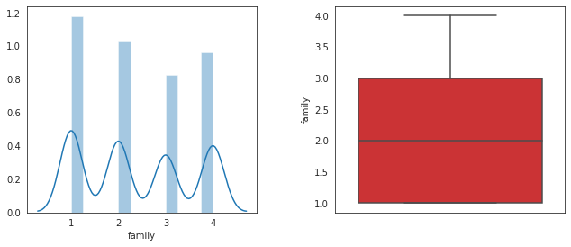

```python
# Main Data
fig, axes = plt.subplots(1, 2, figsize=(10,5))

sns.distplot(X_train["family"], ax=axes[0]);
sns.boxplot(X_train["family"], orient="v", palette="Set1", ax=axes[1])

fig.tight_layout(pad=5.0)
```

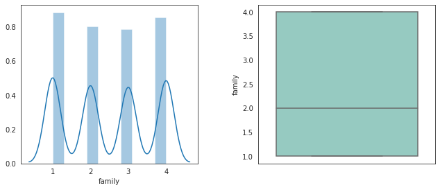

```python
# Upsampled Data
fig, axes = plt.subplots(1, 2, figsize=(10,5))

sns.distplot(X_upsampled_train["family"], ax=axes[0]);
sns.boxplot(X_upsampled_train["family"], orient="v", palette="Set3", ax=axes[1])

fig.tight_layout(pad=5.0)
```

*Observation*: There are no Outliers for the 'Family' feature.

```
Feature 5: 'CC Avg' is our Numerical Interval data.
```

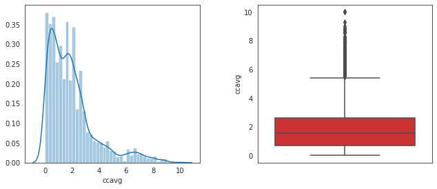

```python
# Main Data
fig, axes = plt.subplots(1, 2, figsize=(10,5))

sns.distplot(X_train["ccavg"], ax=axes[0]);
sns.boxplot(X_train["ccavg"], orient="v", palette="Set1", ax=axes[1])

fig.tight_layout(pad=5.0)
```

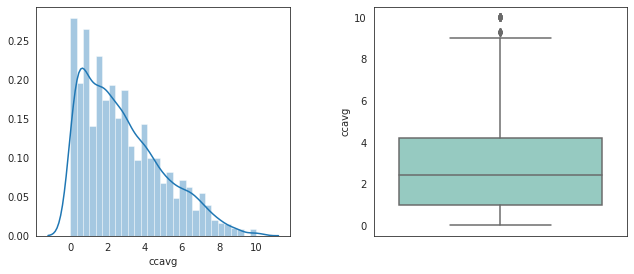

```python
# Upsampled Data
fig, axes = plt.subplots(1, 2, figsize=(10,5))

sns.distplot(X_upsampled_train["ccavg"], ax=axes[0]);
sns.boxplot(X_upsampled_train["ccavg"], orient="v", palette="Set3", ax=axes[1])

fig.tight_layout(pad=5.0)
```

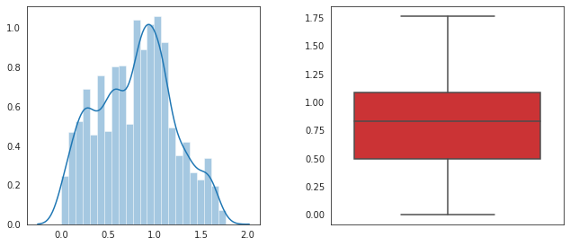

```python
# Transformation on main data X_train
pt_ccavg = PowerTransformer(method="yeo-johnson", standardize=False)

pt_ccavg.fit(X_train["ccavg"].values.reshape(-1, 1))

ptc = pt_ccavg.transform(X_train["ccavg"].values.reshape(-1, 1))

fig, axes = plt.subplots(1, 2, figsize=(10,5))
sns.distplot(ptc, ax=axes[0]);
sns.boxplot(ptc, orient="v", palette="Set1", ax=axes[1])

fig.tight_layout(pad=5.0)
```

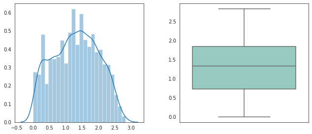

```python
# Transformation on upsampled data X_upsampled_train
pt_ccavgus = PowerTransformer(method="yeo-johnson", standardize=False)

pt_ccavgus.fit(X_upsampled_train["ccavg"].values.reshape(-1, 1))

ptcus = pt_ccavgus.transform(X_upsampled_train["ccavg"].values.reshape(-1, 1))

fig, axes = plt.subplots(1, 2, figsize=(10,5))
sns.distplot(ptcus, ax=axes[0]);
sns.boxplot(ptcus, orient="v", palette="Set3", ax=axes[1])

fig.tight_layout(pad=5.0)
```

*Observation*: The Distribution of 'CC Avg' feature is no longer skewed and there are no Outliers as well.

```
Feature 6: 'Education' is our Ordinal Categorical data.
```

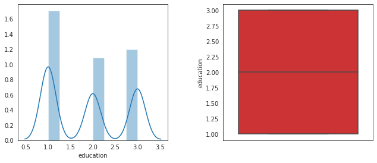

```python
# Main Data
fig, axes = plt.subplots(1, 2, figsize=(10,5))

sns.distplot(X_train["education"], ax=axes[0]);
sns.boxplot(X_train["education"], orient="v", palette="Set1", ax=axes[1])

fig.tight_layout(pad=5.0)
```